# Análisis de sentimientos - noticias financieras

by Geraldine Cacciatore

Junio 2020

## Análisis

En este trabajo vamos a hacer un análisis de texto de un dataset que contiene titulares de noticias financieras, con el objetivo de encontrar las palabras con más repetición según el tipo de sentimiento, y crear un modelo bayeiano que nos prediga el tipo de sentimiento que le genera el titular al lector.

### Lectura de los datos

He descargado los datos de [Kaggle](https://www.kaggle.com/ankurzing/sentiment-analysis-for-financial-news/kernels) y los guardé en mi directorio de la materia. Para abrirlos usamos la función read_csv (no se utilizó la funcion read.csv porque generaba errores).

El dataset contiene dos columnas a las que renombraremos como ‘sentimiento’ y ‘titular’. El sentimiento puede ser negativo, neutral o positivo.

```r
# ----  Cargo librerias
library(readr)

# ----  Cargo datos
all_data <- read_csv('all-data.csv',local = locale(encoding = "latin1"))
#Vemos la dimensión
dim(all_data)
```

```
## [1] 4845    2
```

Cambiamos el nombre de las variables

```r
names(all_data) <- c('sentimiento', 'titular')
```

Vemos la dimensión

```r
#Es un dataset pequeño
dim(all_data)
```

```
## [1] 4845    2
```

Un vistazo

```r
summary(all_data)
```

```
##  sentimiento          titular
##  Length:4845        Length:4845
##  Class :character   Class :character
##  Mode  :character   Mode  :character
```

Pasamos la variable **sentimiento** de clase character a factor

```r
all_data$sentimiento = factor(all_data$sentimiento)
```

Vemos más en detalle los valores de la columna ‘sentimiento’

```r
table(all_data$sentimiento, useNA = 'ifany')
```

```
##
## negative  neutral positive
##      604     2878     1363
```

```r
#Vemos que este dataset no esta balanceado
```

Vemos los resultados gráficamente

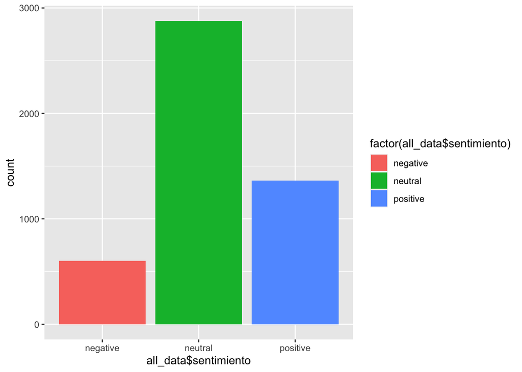

```r
library(ggplot2)
ggplot(all_data, aes(x = all_data$sentimiento, fill = factor(all_data$sentimiento))) + geom_bar()
```

Podemos observar claramente que el dataset esta desbalanceado. Lo que estamos diciendo es que hay bastantes más valores **neutral** (59%) que **positive** (28%) y **negative** (13%). Hay que tener en cuenta esto, porque es importante al momento de dividir un dataset en train y test, o al aplicar algunos algoritmos.

### ETL y Corpus

Ahora vamos a usar la librería **tm**, entre otras cosas para crear un corpus. Para usar la función **corpus**, le pasamos el valor de all_data$titular con **VectorSource()** para decirle que cada vector ha de ser tratado como un documento

```r
library(tm)
datos_corpus <- Corpus(VectorSource(all_data$titular))
```

Vemos la clase y lo que contiene

```r
class(datos_corpus)
```

```
## [1] "SimpleCorpus" "Corpus"
```

Los cinco primeros elementos

```r
inspect(datos_corpus[1:5])
```

```
## <<SimpleCorpus>>
## Metadata:  corpus specific: 1, document level (indexed): 0
## Content:  documents: 5
##
## [1] Technopolis plans to develop in stages an area of no less than 100,000 square meters in order to host companies working in computer technologies and telecommunications , the statement said .
## [2] The international electronic industry company Elcoteq has laid off tens of employees from its Tallinn facility ; contrary to earlier layoffs the company contracted the ranks of its office workers , the daily Postimees reported .
## [3] With the new production plant the company would increase its capacity to meet the expected increase in demand and would improve the use of raw materials and therefore increase the production profitability .
## [4] According to the company 's updated strategy for the years 2009-2012 , Basware targets a long-term net sales growth in the range of 20 % -40 % with an operating profit margin of 10 % -20 % of net sales .
## [5] FINANCING OF ASPOCOMP 'S GROWTH Aspocomp is aggressively pursuing its growth strategy by increasingly focusing on technologically more demanding HDI printed circuit boards PCBs .
```

El tamaño

```r
print(datos_corpus)
```

```
## <<SimpleCorpus>>
## Metadata:  corpus specific: 1, document level (indexed): 0
## Content:  documents: 4845
```

Ahora vamos a usar la función **tm_map** para mejorar el corpus y guardarlo en un nuevo objeto: **corpus_clean**. Esta función tiene distintas funcionalidades. Empezamos por pasar el texto a minúsculas y ver si es necesario para éste análisis quitar los números (en principio las dejaremos).

```r
# Pasar a minúsculas
corpus_clean <- tm_map(datos_corpus, tolower)
```

Vemos cómo quedo

```r
inspect(corpus_clean[1:5])
```

```
## <<SimpleCorpus>>
## Metadata:  corpus specific: 1, document level (indexed): 0
## Content:  documents: 5
##
## [1] technopolis plans to develop in stages an area of no less than 100,000 square meters in order to host companies working in computer technologies and telecommunications , the statement said .
## [2] the international electronic industry company elcoteq has laid off tens of employees from its tallinn facility ; contrary to earlier layoffs the company contracted the ranks of its office workers , the daily postimees reported .
## [3] with the new production plant the company would increase its capacity to meet the expected increase in demand and would improve the use of raw materials and therefore increase the production profitability .
## [4] according to the company 's updated strategy for the years 2009-2012 , basware targets a long-term net sales growth in the range of 20 % -40 % with an operating profit margin of 10 % -20 % of net sales .
## [5] financing of aspocomp 's growth aspocomp is aggressively pursuing its growth strategy by increasingly focusing on technologically more demanding hdi printed circuit boards pcbs .
```

El paquete tm, nos proporciona la posibilidad de eliminar un grupo de palabras del corpus, bien sea pasándole la lista o con funciones específicas. Entre esas funciones, la más importante es **stopwords()** que va a ser la que utilizaremos en este trabajo (se utilizará la versión en inglés).

La siguiente línea le dice a la función **tm_map** que elimine las palabras (**removeWords**) de corpus_clean que están en **stopwords()**

```r
corpus_clean <- tm_map(corpus_clean, removeWords, stopwords())
```

Y ahora vamos a eliminar los simbolos de puntuación con con la opción **removePuntuation**

```r
corpus_clean <- tm_map(corpus_clean, removePunctuation)
```

Después de todos estos pasos, ahora tenemos esto:

```r
inspect(corpus_clean[1:5])
```

```
## <<SimpleCorpus>>
## Metadata:  corpus specific: 1, document level (indexed): 0
## Content:  documents: 5
##
## [1] technopolis plans  develop  stages  area   less  100000 square meters  order  host companies working  computer technologies  telecommunications   statement said
## [2]  international electronic industry company elcoteq  laid  tens  employees   tallinn facility  contrary  earlier layoffs  company contracted  ranks   office workers   daily postimees reported
## [3]   new production plant  company  increase  capacity  meet  expected increase  demand   improve  use  raw materials  therefore increase  production profitability
## [4] according   company s updated strategy   years 20092012  basware targets  longterm net sales growth   range  20  40    operating profit margin  10  20   net sales
## [5] financing  aspocomp s growth aspocomp  aggressively pursuing  growth strategy  increasingly focusing  technologically  demanding hdi printed circuit boards pcbs
```

Como hemos eliminado varias cosas, en esos lugares aparecen espacios. Para limpiarlos continuamos utilizando la mimsa funcion, pero esta vez con la opción **stripWhitespace**

```r
corpus_clean <- tm_map(corpus_clean, stripWhitespace)
```

Vemos las diferencias de los datos iniciales y los finales

#### Inicial

```r
inspect(datos_corpus[1:5])
```

```
## <<SimpleCorpus>>
## Metadata:  corpus specific: 1, document level (indexed): 0
## Content:  documents: 5
##
## [1] Technopolis plans to develop in stages an area of no less than 100,000 square meters in order to host companies working in computer technologies and telecommunications , the statement said .
## [2] The international electronic industry company Elcoteq has laid off tens of employees from its Tallinn facility ; contrary to earlier layoffs the company contracted the ranks of its office workers , the daily Postimees reported .
## [3] With the new production plant the company would increase its capacity to meet the expected increase in demand and would improve the use of raw materials and therefore increase the production profitability .
## [4] According to the company 's updated strategy for the years 2009-2012 , Basware targets a long-term net sales growth in the range of 20 % -40 % with an operating profit margin of 10 % -20 % of net sales .
## [5] FINANCING OF ASPOCOMP 'S GROWTH Aspocomp is aggressively pursuing its growth strategy by increasingly focusing on technologically more demanding HDI printed circuit boards PCBs .
```

#### Limpio

```r
inspect(corpus_clean[1:5])
```

```
## <<SimpleCorpus>>
## Metadata:  corpus specific: 1, document level (indexed): 0
## Content:  documents: 5
##
## [1] technopolis plans develop stages area less 100000 square meters order host companies working computer technologies telecommunications statement said
## [2]  international electronic industry company elcoteq laid tens employees tallinn facility contrary earlier layoffs company contracted ranks office workers daily postimees reported
## [3]  new production plant company increase capacity meet expected increase demand improve use raw materials therefore increase production profitability
## [4] according company s updated strategy years 20092012 basware targets longterm net sales growth range 20 40 operating profit margin 10 20 net sales
## [5] financing aspocomp s growth aspocomp aggressively pursuing growth strategy increasingly focusing technologically demanding hdi printed circuit boards pcbs
```

### Document-Term Matrix

Ahora vamos a crear una matriz dtm (document-term matrix). Son matrices en las que se representan los términos que aparecen en el documento y con qué frecuencia

```r
datos_dtm <- DocumentTermMatrix(corpus_clean)
datos_dtm
```

```
## <<DocumentTermMatrix (documents: 4845, terms: 10809)>>
## Non-/sparse entries: 57972/52311633
## Sparsity           : 100%
## Maximal term length: 25
## Weighting          : term frequency (tf)
```

Este objeto es de clase DTM

```r
class(datos_dtm)
```

```
## [1] "DocumentTermMatrix"    "simple_triplet_matrix"
```

Vemos la estructura del documento

```r
names(datos_dtm)
```

```
## [1] "i"        "j"        "v"        "nrow"     "ncol"     "dimnames"
```

Las filas son los documentos, en nuestro caso los titulares

```r
datos_dtm$nrow
```

```
## [1] 4845
```

Las columnas son las palabras que han ido apareciendo

```r
datos_dtm$ncol
```

```
## [1] 10809
```

Tenemos 10809 palabras distintas

**datos_dtm** almacena cuantas veces aparece cada una de esas 10809 palabras en cada uno de los 4845 documentos.

Una celda concreta corresponde a un documento (en este caso un titular) concreto que se cruza con uno de los posibles términos distinto y el valor que aparece en esa celda es el número de repeticiones

Vemos que tenemos:

```r
str(datos_dtm)
```

```
## List of 6
##  $ i       : int [1:57972] 1 1 1 1 1 1 1 1 1 1 ...
##  $ j       : int [1:57972] 1 2 3 4 5 6 7 8 9 10 ...
##  $ v       : num [1:57972] 1 1 1 1 1 1 1 1 1 1 ...
##  $ nrow    : int 4845
##  $ ncol    : int 10809
##  $ dimnames:List of 2
##   ..$ Docs : chr [1:4845] "1" "2" "3" "4" ...
##   ..$ Terms: chr [1:10809] "100000" "area" "companies" "computer" ...
##  - attr(*, "class")= chr [1:2] "DocumentTermMatrix" "simple_triplet_matrix"
##  - attr(*, "weighting")= chr [1:2] "term frequency" "tf"
```

Podemos identifcar esa estructura:

- Los documentos (4845), aparecen cómo **Docs** y cómo filas **nrow**
- Los términos (10809), aparecen cómo **Terms** y cómo columnas **ncol**

### Dividir el dataset (Train / Test)

Ahora vamos a intentar hacer un modelo que prediga el sentimiento según el titular. Para realizarlo, dividimos el dataset en dos, uno de train y otro de test y lo vamos a hacer de forma que la proporción del tipo de sentimiento se mantenga. Esto es muy importante cuando el dataset está desbalanceado (como vimos que se cumple en este caso) y hay más valores de un tipo que de otro.

```r
# Damos un 80% al train y 20% al test
library(caret)
# Antes creamos una semilla para que siempre se den los mismos resultados
set.seed(1234)

# Creamos una copia de 'all_data' en formato de data frame para poder asignar el train y tesat
all_data2 = data.frame(all_data)

# Creamos un índice que mantenga esa proporción
index         <- createDataPartition(all_data2$sentimiento, p=0.8, list=FALSE)

all_data_train <- all_data2[ index,]
all_data_test  <- all_data2[-index,]
```

Tener en cuenta que estamos haciendo el modelo con los datos en bruto

Para el dtm

```r
# La datos de train
datos_dtm_train <- datos_dtm[ index, ]

# Los datos de test
datos_dtm_test  <- datos_dtm[-index, ]
```

Hacemos lo mismo para el corpus

```r
datos_corpus_train <- corpus_clean[index]
datos_corpus_test  <- corpus_clean[-index]
```

Chequeamos las proporciones entre los tipos de sentiminetos que tenemos

```r
# En train
prop.table(table(all_data_train$sentimiento))
```

```
##
##  negative   neutral  positive
## 0.1248066 0.5938628 0.2813306
```

```r
# En test
prop.table(table(all_data_test$sentimiento))
```

```
##
##  negative   neutral  positive
## 0.1240951 0.5946225 0.2812823
```

Vemos que las proporciones son similares

Antes de continuar vamos a hacer una visualización con word cloud de las palabras que más aparecen

### Word cloud (nube de palabras)

Nos quedamos sólo con las que aparezcan al menos 40 veces

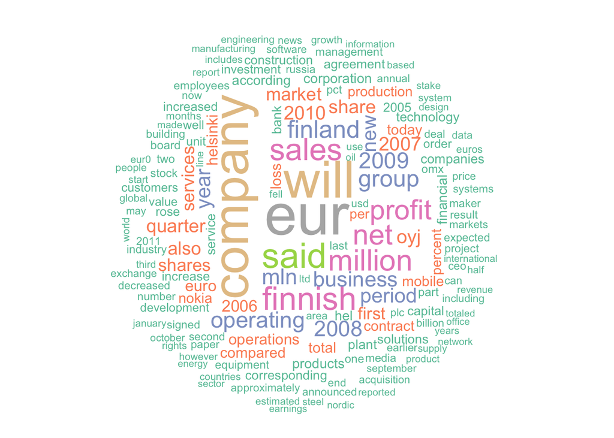

```r
library(wordcloud)
wordcloud(datos_corpus_train, min.freq = 40, random.order = FALSE,colors = brewer.pal(8, "Set2"))
```

Ahora vamos a realizar otro word club pero por tipo de sentimiento.

```r
negative <- subset(all_data_train, sentimiento == "negative")
neutral  <- subset(all_data_train, sentimiento == "neutral")
positive  <- subset(all_data_train, sentimiento == "positive")
```

#### Negative

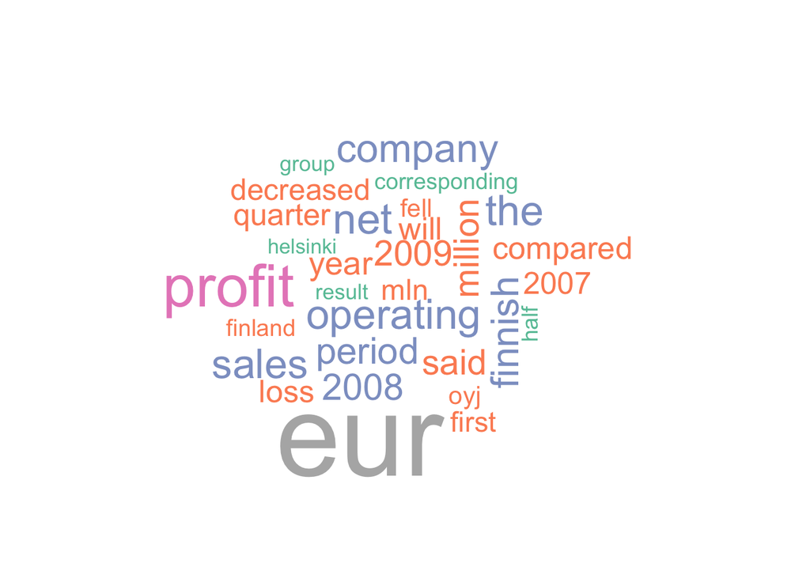

```r
wordcloud(negative$titular, max.words = 30, scale = c(6, 0.5),colors = brewer.pal(8, "Set2"))
```

#### Neutral

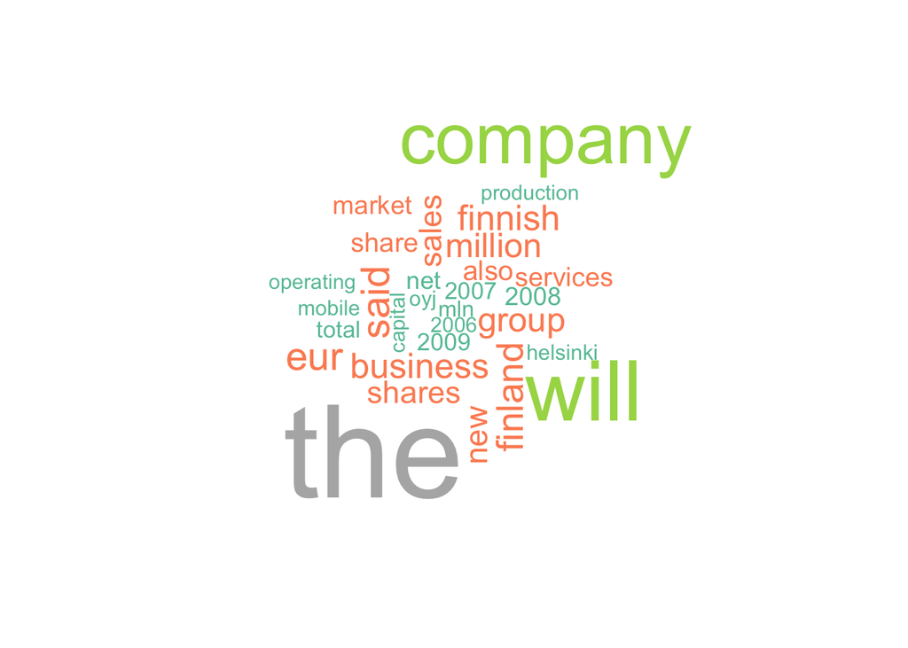

```r
wordcloud(neutral$titular, max.words = 30, scale = c(6, 0.5), colors = brewer.pal(8, "Set2"))
```

#### Positive

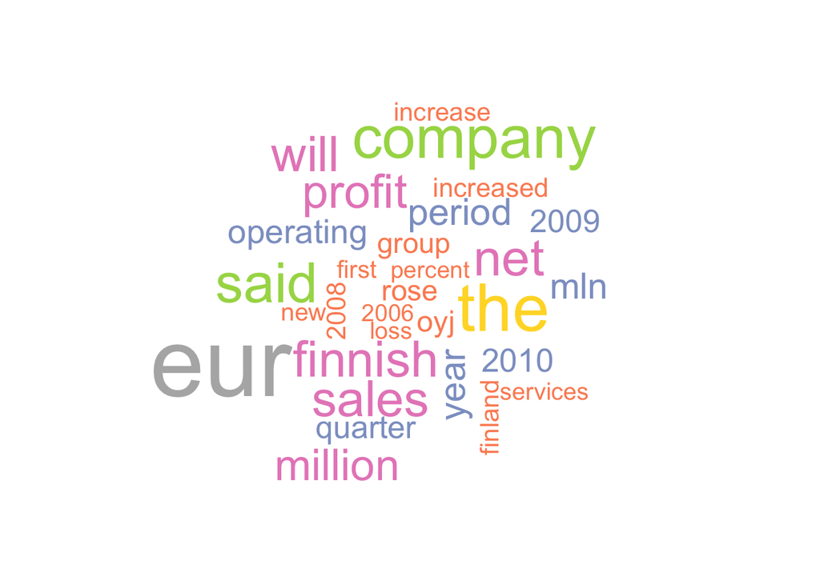

```r
wordcloud(positive$titular, max.words = 30, scale = c(5, 0.5),colors = brewer.pal(8, "Set2"))
```

Se puede ver a simple vista que cambian las pablabras que dominan para cada grupo.

### Palabras frecuentes

La lista de términos con una frecuencia mínima de 40

```r
findFreqTerms(datos_dtm_train, 40)
```

```
##   [1] "area"          "companies"     "order"         "said"
##   [5] "company"       "earlier"       "employees"     "industry"
##   [9] "international" "office"        "reported"      "expected"
##  [13] "increase"      "new"           "plant"         "production"
##  [17] "use"           "according"     "growth"        "net"
##  [21] "operating"     "profit"        "sales"         "years"
##  [25] "2010"          "last"          "loss"          "period"
##  [29] "quarter"       "year"          "eur"           "increased"
##  [33] "third"         "2007"          "corresponding" "rose"
##  [37] "business"      "customers"     "line"          "first"
##  [41] "nordic"        "shares"        "value"         "agreement"
##  [45] "finland"       "oil"           "oyj"           "per"
##  [49] "september"     "signed"        "2005"          "finnish"
##  [53] "totaled"       "compared"      "eur0"          "2006"
##  [57] "announced"     "earnings"      "helsinki"      "nokia"
```

[output cut: 26 more lines]

### Diccionario

Ahora vamos a crear un diccionario con las palabras con un número mínimo de apariciones de 5.

```r
Dictionary <- function(x) {
    if( is.character(x) ) {
        return (x)
    }
    stop('x is not a character vector')
}
```

La aplicamos el diccionario en el train

```r
datos_dict  <- Dictionary(findFreqTerms(datos_dtm_train, 5))
head(datos_dict)
```

```
## [1] "100000"    "area"      "companies" "computer"  "develop"   "less"
```

Para train y test

```r
datos_train <- DocumentTermMatrix(datos_corpus_train, list(dictionary = datos_dict))
datos_test  <- DocumentTermMatrix(datos_corpus_test, list(dictionary = datos_dict))
```

Creamos una función que convierte el número de apariciones en un contador de tipo factor Si/No

```r
convert.counts <- function(x) {
      x <- ifelse(x > 0, 1, 0)
      x <- factor(x, levels = c(0, 1), labels = c("No", "Si"))
}
```

Y lo aplicamos a datos_train y datos_test

```r
datos_train <- apply(datos_train, MARGIN = 2, convert.counts)
datos_test  <- apply(datos_test, MARGIN = 2, convert.counts)
```

### Modelo Bayesiano Naive

Vamos a crear un modelo bayesiano

```r
library(e1071)
set.seed(1234)
datos_classifier <- naiveBayes(datos_train, all_data_train$sentimiento)
```

Predecimos en el dataset de test

```r
datos_test_pred <- predict(datos_classifier, datos_test)
```

Vemos que tal hemos hecho la predicción

```r
library(gmodels)
CrossTable(datos_test_pred, all_data_test$sentimiento,
           prop.chisq = FALSE, prop.t = FALSE, prop.r = FALSE,
           dnn = c('predicted', 'actual'))
```

```
##
##
##    Cell Contents
## |-------------------------|
## |                       N |
## |           N / Col Total |
## |-------------------------|
##
##
## Total Observations in Table:  967
##
##
##              | actual
##    predicted |  negative |   neutral |  positive | Row Total |
## -------------|-----------|-----------|-----------|-----------|
##     negative |        71 |        45 |        53 |       169 |
##              |     0.592 |     0.078 |     0.195 |           |
## -------------|-----------|-----------|-----------|-----------|
##      neutral |        35 |       475 |        98 |       608 |
##              |     0.292 |     0.826 |     0.360 |           |
## -------------|-----------|-----------|-----------|-----------|
##     positive |        14 |        55 |       121 |       190 |
##              |     0.117 |     0.096 |     0.445 |           |
## -------------|-----------|-----------|-----------|-----------|
## Column Total |       120 |       575 |       272 |       967 |
##              |     0.124 |     0.595 |     0.281 |           |
## -------------|-----------|-----------|-----------|-----------|
##
##
```

La tabla anterior es una [matriz de confusión](https://es.wikipedia.org/wiki/Matriz_de_confusi%C3%B3n) donde cruzamos datos reales (actual) con predicciones (predicted). Lo ideal es que todos los valores estén en la diagonal, es decir que las predicciones **negative** sean realmente **negative**, las **neutral** sean realmente **neutral** y las predicciones **positive** sean realmente **positive**

### Mejoramos el modelo

Modificamos un poco los parámetros con el objetivo de intentar mejorar el modelo

```r
# Entrenamos
datos_classifier2 <- naiveBayes(datos_train, all_data_train$sentimiento, laplace = 1)

# Predecimos
datos_test_pred2  <- predict(datos_classifier2, datos_test)

# Y mostramos el rersultado
CrossTable(datos_test_pred2, all_data_test$sentimiento,
           prop.chisq = FALSE, prop.t = FALSE, prop.r = FALSE,
           dnn = c('predicted', 'actual'),colors = brewer.pal(8, "Set2"))
```

```
##
##
##    Cell Contents
## |-------------------------|
## |                       N |
## |           N / Col Total |
## |-------------------------|
##
##
## Total Observations in Table:  967
##
##
##              | actual
##    predicted |  negative |   neutral |  positive | Row Total |
## -------------|-----------|-----------|-----------|-----------|
##     negative |        62 |        25 |        31 |       118 |
##              |     0.517 |     0.043 |     0.114 |           |
## -------------|-----------|-----------|-----------|-----------|
##      neutral |        39 |       507 |       115 |       661 |
##              |     0.325 |     0.882 |     0.423 |           |
## -------------|-----------|-----------|-----------|-----------|
##     positive |        19 |        43 |       126 |       188 |
##              |     0.158 |     0.075 |     0.463 |           |
## -------------|-----------|-----------|-----------|-----------|
## Column Total |       120 |       575 |       272 |       967 |
##              |     0.124 |     0.595 |     0.281 |           |
## -------------|-----------|-----------|-----------|-----------|
##
##
```

Este modelo ha predicho que hay 118 valores **negative** y ha acertado en 62 y se ha equivocado en 56. Por otro lado, ha dicho que hay 661 valores de **neutral** y ha acertado en 507 y se ha equivocado en 154. Finalmente, ha predecido que hay 188 valores **positive** y ha hacertado en 126, equivocandose en 62. En total ha acertado 695 (62 + 507 + 126) de 967. Un 72%

Este modelo es un poco mejor.

## Conclusiones

En base a este pequeño estudio podemos concluir que:

- Casi el 60% de los titulares no generan un sentimiento positivo ni negativo
- Se puede ver que las palabras que mayor se repiten por sentimiento son visualmente diferentes
- El modelo creado no ha sido de lo mejor, pero finalmente con la mejora realizada, ha podido acertar en el 72% de los datos.